# P2data607

Author

xiaofei

## **Introduction**

The task is to choose three datasets from the week’s class discussion to practice transforming wide-format datasets into tidy formats suitable for downstream analysis.

The three datasets I choose are: 1)world GDP by country; 2)Japanese population density; 3)a made up datsets about takeout spending habit by generation. The following process steps will be performed on each of the datasets individually:

- Create a .CSV file that includes all of the information included in the dataset.
- Read the information from your .CSV file into R, and use tidyr and dplyr as needed to tidy and transform your data.
- Perform the analysis requested.
- Code R Markdown file, posted to rpubs.com, and should include narrative descriptions of your data cleanup work, analysis, and conclusions.

## **Dataset 1: World GDP by Country: 1960-2022**

Import and load dataset. Original data has dimensions of 266 rows and 65 columns. After transformation to the long format, the new datasets has only 4 columns and 16758 rows. This long format is grouped in a way that’s easier for analysis, filtering and visualization. We are ready for the next step - analysis.

```r
library(tidyr)
library(dplyr)
library(ggplot2)

# create df to read the CSV file from my github repository
gdp_data <- read.csv("https://raw.githubusercontent.com/xiaofeimei1/sale-trend-analysis/refs/heads/main/GDP.csv",
                     stringsAsFactors = FALSE,
                     check.names = FALSE)

print("origional columns:")
```

```
[1] "origional columns:"
```

```r
print(names(gdp_data))
```

```
 [1] "Country"      "Country Code" "1960"         "1961"         "1962"
 [6] "1963"         "1964"         "1965"         "1966"         "1967"
[11] "1968"         "1969"         "1970"         "1971"         "1972"
[16] "1973"         "1974"         "1975"         "1976"         "1977"
[21] "1978"         "1979"         "1980"         "1981"         "1982"
[26] "1983"         "1984"         "1985"         "1986"         "1987"
[31] "1988"         "1989"         "1990"         "1991"         "1992"
[36] "1993"         "1994"         "1995"         "1996"         "1997"
[41] "1998"         "1999"         "2000"         "2001"         "2002"
[46] "2003"         "2004"         "2005"         "2006"         "2007"
[51] "2008"         "2009"         "2010"         "2011"         "2012"
[56] "2013"         "2014"         "2015"         "2016"         "2017"
[61] "2018"         "2019"         "2020"         "2021"         "2022"
```

```r
print("Structure of original data:")
```

```
[1] "Structure of original data:"
```

```r
str(gdp_data)
```

```
'data.frame':   266 obs. of  65 variables:
 $ Country     : chr  "Aruba" "Africa Eastern and Southern" "Afghanistan" "Africa Western and Central" ...
 $ Country Code: chr  "ABW" "AFE" "AFG" "AFW" ...
 $ 1960        : num  NA 2.11e+10 5.38e+08 1.04e+10 NA ...
 $ 1961        : num  NA 2.16e+10 5.49e+08 1.12e+10 NA ...
 $ 1962        : num  NA 2.35e+10 5.47e+08 1.20e+10 NA ...
 $ 1963        : num  NA 2.80e+10 7.51e+08 1.27e+10 NA ...
 $ 1964        : num  NA 2.59e+10 8.00e+08 1.39e+10 NA ...
 $ 1965        : num  NA 2.95e+10 1.01e+09 1.49e+10 NA ...
 $ 1966        : num  NA 3.20e+10 1.40e+09 1.59e+10 NA ...
 $ 1967        : num  NA 3.33e+10 1.67e+09 1.45e+10 NA ...
 $ 1968        : num  NA 3.63e+10 1.37e+09 1.50e+10 NA ...
 $ 1969        : num  NA 4.16e+10 1.41e+09 1.70e+10 NA ...
 $ 1970        : num  NA 4.46e+10 1.75e+09 2.36e+10 NA ...
 $ 1971        : num  NA 4.92e+10 1.83e+09 2.09e+10 NA ...
```

[output cut: 51 more lines]

```r
# Show first few rows
print("First few rows of original data:")
```

```
[1] "First few rows of original data:"
```

```r
print(head(gdp_data))
```

```
                      Country Country Code        1960        1961        1962
1                       Aruba          ABW          NA          NA          NA
2 Africa Eastern and Southern          AFE 21125015452 21616228139 23506279900
3                 Afghanistan          AFG   537777811   548888896   546666678
4  Africa Western and Central          AFW 10447637853 11173212080 11990534018
5                      Angola          AGO          NA          NA          NA
6                     Albania          ALB          NA          NA          NA
         1963        1964        1965        1966        1967        1968
1          NA          NA          NA          NA          NA          NA
2 28048360188 25920665260 29472103270 32014368121 33269509510 36327785495
3   751111191   800000044  1006666638  1399999967  1673333418  1373333367
4 12727688165 13898109284 14929792388 15910837742 14510579889 14968235782
5          NA          NA          NA          NA          NA          NA
6          NA          NA          NA          NA          NA          NA
         1969        1970        1971        1972        1973        1974
```

[output cut: 62 more lines]

```r
# Transform from wide to long format
gdp_long <- gdp_data |>
  pivot_longer(
    cols = -c(Country, `Country Code`),
    names_to = "Year",
    values_to = "GDP"
  ) |>
  mutate(
    Year = as.integer(Year),
    GDP = as.numeric(GDP)
  ) |>
  arrange(Country, Year)

# Show new dataset
print("Transformed data column names:")
```

```
[1] "Transformed data column names:"
```

```r
print(names(gdp_long))
```

```
[1] "Country"      "Country Code" "Year"         "GDP"
```

```r
print("Structure of transformed data:")
```

```
[1] "Structure of transformed data:"
```

```r
str(gdp_long)
```

```
tibble [16,758 × 4] (S3: tbl_df/tbl/data.frame)
 $ Country     : chr [1:16758] "Afghanistan" "Afghanistan" "Afghanistan" "Afghanistan" ...
 $ Country Code: chr [1:16758] "AFG" "AFG" "AFG" "AFG" ...
 $ Year        : int [1:16758] 1960 1961 1962 1963 1964 1965 1966 1967 1968 1969 ...
 $ GDP         : num [1:16758] 5.38e+08 5.49e+08 5.47e+08 7.51e+08 8.00e+08 ...
```

```r
print("First 20 rows of transformed dataset:")
```

```
[1] "First 20 rows of transformed dataset:"
```

```r
print(head(gdp_long, 20))
```

```
# A tibble: 20 × 4
   Country     `Country Code`  Year         GDP
   <chr>       <chr>          <int>       <dbl>
 1 Afghanistan AFG             1960  537777811.
 2 Afghanistan AFG             1961  548888896.
 3 Afghanistan AFG             1962  546666678.
 4 Afghanistan AFG             1963  751111191.
 5 Afghanistan AFG             1964  800000044.
 6 Afghanistan AFG             1965 1006666638
 7 Afghanistan AFG             1966 1399999967
 8 Afghanistan AFG             1967 1673333418
 9 Afghanistan AFG             1968 1373333367
10 Afghanistan AFG             1969 1408888922
11 Afghanistan AFG             1970 1748886596
12 Afghanistan AFG             1971 1831108971
13 Afghanistan AFG             1972 1595555476
14 Afghanistan AFG             1973 1733333264
15 Afghanistan AFG             1974 2155555498
16 Afghanistan AFG             1975 2366666616
17 Afghanistan AFG             1976 2555555567
18 Afghanistan AFG             1977 2953333418
19 Afghanistan AFG             1978 3300000109
20 Afghanistan AFG             1979 3697940410
```

```r
print("Summary of Year column:")
```

```
[1] "Summary of Year column:"
```

```r
print(summary(gdp_long$Year))
```

```
   Min. 1st Qu.  Median    Mean 3rd Qu.    Max.
   1960    1975    1991    1991    2007    2022
```

Analysis and visualization. From the results shown below, The GDP dataset contains observations from 1960 to 2022. Since we GDP data listed for each year, we can do analysis on the GDP trend, such as find out which region has the top 10 growing GDP. I will also plot contry GDP but group them in regions to find out a a macro trend globally. In the end show plots to conclude analysis for this first dataset.

```r
# 1. BASIC SUMMARY STATISTICS
print(paste("Total countries:", length(unique(gdp_long$Country))))
```

```
[1] "Total countries: 266"
```

```r
print(paste("Time period:", min(gdp_long$Year, na.rm = TRUE), "to", max(gdp_long$Year, na.rm = TRUE)))
```

```
[1] "Time period: 1960 to 2022"
```

```r
print(paste("Total observations:", nrow(gdp_long)))
```

```
[1] "Total observations: 16758"
```

```r
# top 10 economies in the most recent year (2022)
top_economies_2022 <- gdp_long |>
  filter(Year == 2022 & !is.na(GDP)) |>
  arrange(desc(GDP)) |>
  head(10) |>
  pull(Country)

print("Top 10 economies in 2022:")
```

```
[1] "Top 10 economies in 2022:"
```

```r
print(top_economies_2022)
```

```
 [1] "World"                     "High income"
 [3] "OECD members"              "Post-demographic dividend"
 [5] "IDA & IBRD total"          "Low & middle income"
 [7] "Middle income"             "IBRD only"
 [9] "East Asia & Pacific"       "Upper middle income"
```

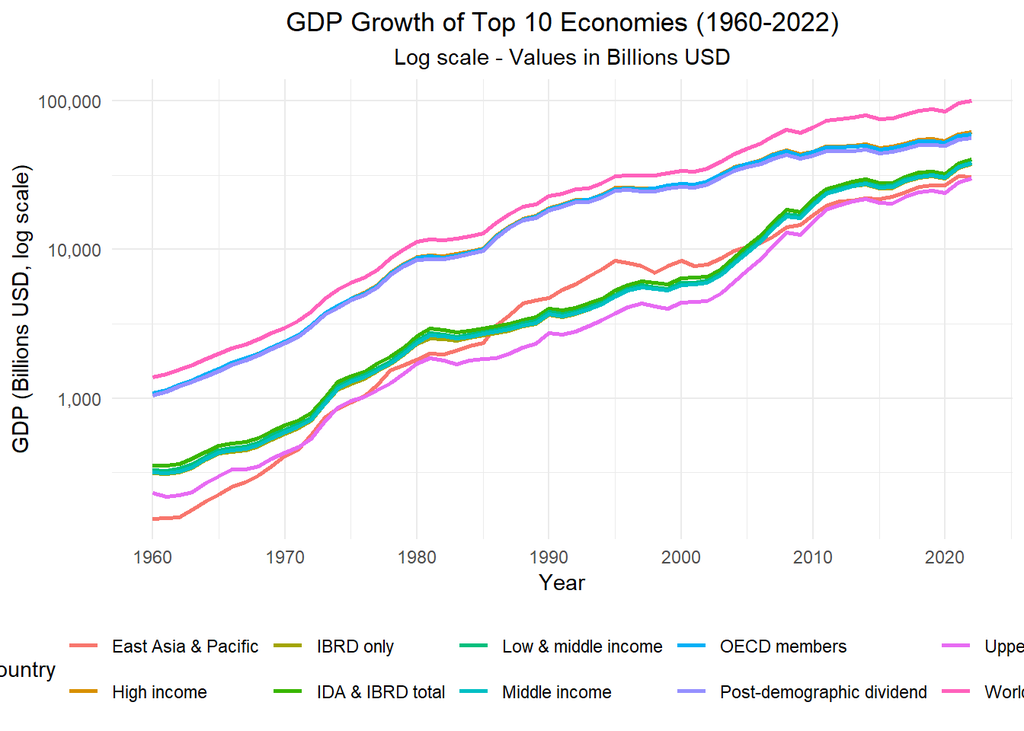

```r
# VISUALIZATIONS

# Visualization 1: Top 10 Economies Growth Over Time (1960-2022)
top_gdp_data <- gdp_long |>
  filter(Country %in% top_economies_2022 & !is.na(GDP))

ggplot(top_gdp_data, aes(x = Year, y = GDP/1e9, color = Country)) +
  geom_line(size = 1) +
  scale_y_log10(labels = scales::comma) +
  labs(title = "GDP Growth of Top 10 Economies (1960-2022)",
       subtitle = "Log scale - Values in Billions USD",
       x = "Year",
       y = "GDP (Billions USD, log scale)",
       color = "Country") +
  theme_minimal() +
  theme(legend.position = "bottom",
        plot.title = element_text(hjust = 0.5),
        plot.subtitle = element_text(hjust = 0.5)) +
  scale_x_continuous(breaks = seq(1960, 2020, by = 10))
```

[figure not shown]

```r
# Global GDP Trend
global_trend <- gdp_long |>
  group_by(Year)|>
  summarise(World_GDP = sum(GDP, na.rm = TRUE) / 1e9)  # in unit billions

ggplot(global_trend, aes(x = Year, y = World_GDP)) +
  geom_line(color = "darkblue", size = 1.2) +
  geom_point(color = "darkblue", size = 0.5) +
  labs(title = "Global GDP Trend (1960-2022)",
       subtitle = "Total World GDP in Billions USD",
       x = "Year",
       y = "World GDP (Billions USD)") +
  theme_minimal() +
  scale_x_continuous(breaks = seq(1960, 2020, by = 5)) +
  scale_y_continuous(labels = scales::comma)
```

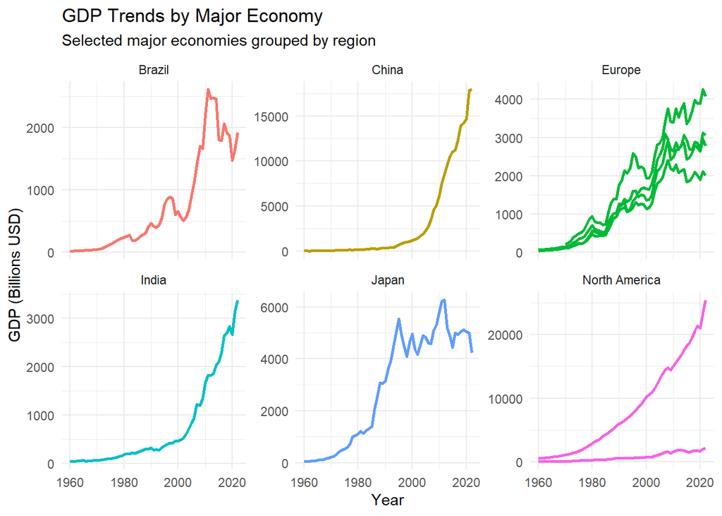

```r
# Create a simple region classification and compare trend
major_economies_list <- c("United States", "China", "Japan", "Germany", "United Kingdom","France", "India", "Brazil", "Canada", "Italy", "Russia")

# Filter the data for these major economies
major_economies <- gdp_long |>
  filter(Country %in% major_economies_list & !is.na(GDP))

# Create region classification
major_economies <- major_economies |>
  mutate(Region = case_when(
    Country %in% c("United States", "Canada") ~ "North America",
    Country %in% c("Germany", "United Kingdom", "France", "Italy") ~ "Europe",
    Country == "China" ~ "China",
    Country == "India" ~ "India",
    Country == "Japan" ~ "Japan",
    Country == "Brazil" ~ "Brazil",
    Country == "Russia" ~ "Russia",
    TRUE ~ "Other"
  ))

# Plot regional comparison
ggplot(major_economies, aes(x = Year, y = GDP/1e9, color = Region, group = Country)) +
  geom_line(size = 1) +
  facet_wrap(~Region, scales = "free_y") +
  labs(title = "GDP Trends by Major Economy",
       subtitle = "Selected major economies grouped by region",
       x = "Year",
       y = "GDP (Billions USD)") +
  theme_minimal() +
  theme(legend.position = "none") +
  scale_x_continuous(breaks = seq(1960, 2020, by = 20))
```

## **Dataset 2: Japanese 2015 Population Density**

This is a dataset about Japanese population in different cities. City names were spread out in multiple columns, total 47 in the original dataset. Goal is transform dataset to long format, new column city_name will be created to group those cities in one single column, population density will be grouped under column name population_density. We will check and compare columns between original dataset with the transformed dataset in the following code chunk:

```r
library(tidyr)
library(dplyr)

# Read the  population density CSV file from my github repository
population_data <- read.csv("https://raw.githubusercontent.com/xiaofeimei1/sale-trend-analysis/refs/heads/main/prefecturepopdensity2015.csv",
                            stringsAsFactors = FALSE,
                            check.names = FALSE,
                            header = TRUE)

# original column names
print("Original columns in population dataset:")
```

```
[1] "Original columns in population dataset:"
```

```r
print(names(population_data))
```

```
 [1] "Aichi"     "Akita"     "Aomori"    "Chiba"     "Ehime"     "Fukui"
 [7] "Fukuoka"   "Fukushima" "Gifu"      "Gumma"     "Hiroshima" "Hokkaido"
[13] "Hyogo"     "Ibaraki"   "Ishikawa"  "Iwate"     "Kagawa"    "Kagoshima"
[19] "Kanagawa"  "Kochi"     "Kumamoto"  "Kyoto"     "Mie"       "Miyagi"
[25] "Miyazaki"  "Nagano"    "Nagasaki"  "Nara"      "Niigata"   "Oita"
[31] "Okayama"   "Okinawa"   "Osaka"     "Saga"      "Saitama"   "Shiga"
[37] "Shimane"   "Shizuoka"  "Tochigi"   "Tokushima" "Tokyo"     "Tottori"
[43] "Toyama"    "Wakayama"  "Yamagata"  "Yamaguchi" "Yamanashi"
```

```r
# structure
print("Structure of original population data:")
```

```
[1] "Structure of original population data:"
```

```r
str(population_data)
```

```
'data.frame':   1 obs. of  47 variables:
 $ Aichi    : num 1447
 $ Akita    : num 87.9
 $ Aomori   : num 136
 $ Chiba    : num 1207
 $ Ehime    : num 244
 $ Fukui    : num 188
 $ Fukuoka  : num 1023
 $ Fukushima: num 139
 $ Gifu     : num 191
 $ Gumma    : num 310
 $ Hiroshima: num 336
 $ Hokkaido : num 68.6
 $ Hyogo    : num 659
 $ Ibaraki  : num 479
```

[output cut: 33 more lines]

```r
# Show first few rows of original data
print(head(population_data))
```

```
   Aichi Akita Aomori  Chiba Ehime Fukui Fukuoka Fukushima  Gifu Gumma
1 1446.9  87.9  135.7 1206.8 244.2 187.8  1023.4     138.8 191.4 310.2
  Hiroshima Hokkaido Hyogo Ibaraki Ishikawa Iwate Kagawa Kagoshima Kanagawa
1     335.5     68.6 659.1   478.6    275.8  83.8  520.5     179.4   3778.2
  Kochi Kumamoto Kyoto   Mie Miyagi Miyazaki Nagano Nagasaki  Nara Niigata Oita
1 102.5    241.2 565.9 314.5  320.5    142.8  154.8    333.4 369.8   183.2  184
  Okayama Okinawa  Osaka  Saga Saitama Shiga Shimane Shizuoka Tochigi Tokushima
1   270.2   628.7 4639.9 341.4    1912 351.8   103.5    475.8   308.2     182.3
   Tokyo Tottori Toyama Wakayama Yamagata Yamaguchi Yamanashi
1 6168.1   163.6  251.2      204    120.4     229.9       187
```

```r
# Transform from wide to long format
population_long <- population_data |>
  pivot_longer(
    cols = everything(),
    names_to = "city_name",
    values_to = "population_density"
  ) |>
  mutate(
    population_density = as.numeric(population_density),
    city_name = as.character(city_name)
  ) |>
  arrange(city_name)

# Show transformed dataset results
print("Transformed data column names:")
```

```
[1] "Transformed data column names:"
```

```r
print(names(population_long))
```

```
[1] "city_name"          "population_density"
```

```r
print("Structure of transformed data:")
```

```
[1] "Structure of transformed data:"
```

```r
str(population_long)
```

```
tibble [47 × 2] (S3: tbl_df/tbl/data.frame)
 $ city_name         : chr [1:47] "Aichi" "Akita" "Aomori" "Chiba" ...
 $ population_density: num [1:47] 1446.9 87.9 135.7 1206.8 244.2 ...
```

```r
print("First 20 rows of transformed dataset:")
```

```
[1] "First 20 rows of transformed dataset:"
```

```r
print(head(population_long, 20))
```

```
# A tibble: 20 × 2
   city_name population_density
   <chr>                  <dbl>
 1 Aichi                 1447.
 2 Akita                   87.9
 3 Aomori                 136.
 4 Chiba                 1207.
 5 Ehime                  244.
 6 Fukui                  188.
 7 Fukuoka               1023.
 8 Fukushima              139.
 9 Gifu                   191.
10 Gumma                  310.
11 Hiroshima              336.
12 Hokkaido                68.6
13 Hyogo                  659.
14 Ibaraki                479.
15 Ishikawa               276.
16 Iwate                   83.8
17 Kagawa                 520.
18 Kagoshima              179.
19 Kanagawa              3778.
20 Kochi                  102.
```

```r
print(paste("Total rows:", nrow(population_long)))
```

```
[1] "Total rows: 47"
```

```r
print(paste("Number of prefectures:", length(unique(population_long$city_name))))
```

```
[1] "Number of prefectures: 47"
```

After getting the long format, we are ready to do population analysis and visualization. As shown below, top cities that has most dense population are: Tokyo, Osaka, Kanagawa… On the other hand, lowest cities with population density are Hokkaido, Iwate, Akita… To show how population were largely concentrate on the top 3 cities, we can see the last visualization that those 3 cities are far more dense compare to other cities.

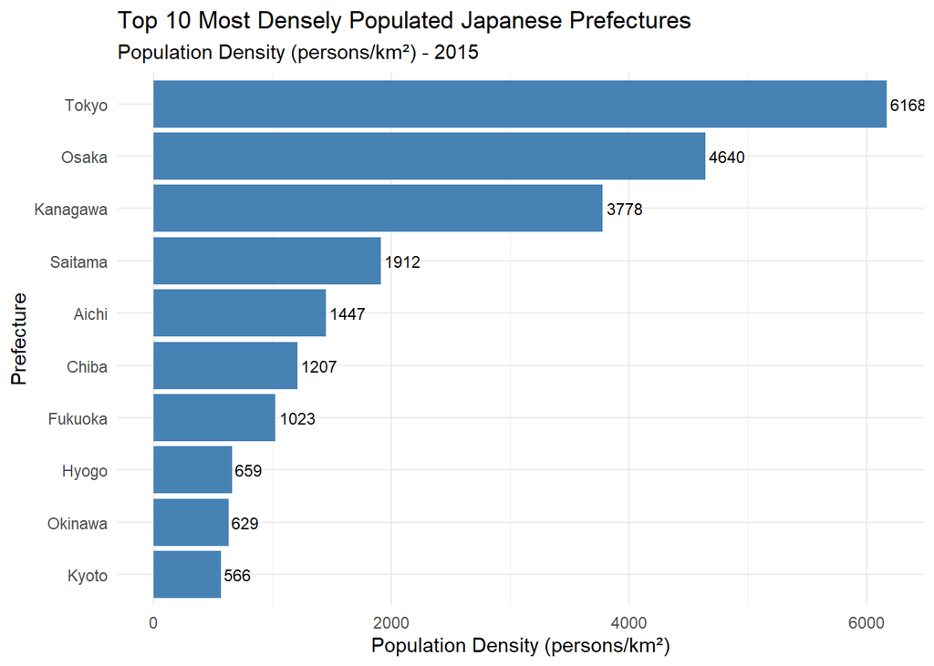

```r
top_dense <- population_long |>
  arrange(desc(population_density)) |>
  head(10)

bottom_dense <- population_long |>
  arrange(population_density) |>
  head(10)

# Bar chart of top 10 most dense prefectures
ggplot(top_dense, aes(x = reorder(city_name, population_density), y = population_density)) +
  geom_bar(stat = "identity", fill = "steelblue") +
  coord_flip() +
  labs(title = "Top 10 Most Densely Populated Japanese Prefectures",
       subtitle = "Population Density (persons/km²) - 2015",
       x = "Prefecture",
       y = "Population Density (persons/km²)") +
  theme_minimal() +
  geom_text(aes(label = round(population_density, 0)), hjust = -0.1, size = 3)
```

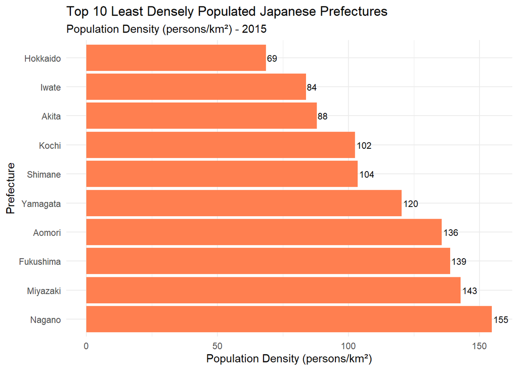

```r
# Bar chart of bottom 10 least dense prefectures
ggplot(bottom_dense, aes(x = reorder(city_name, desc(population_density)), y = population_density)) +
  geom_bar(stat = "identity", fill = "coral") +
  coord_flip() +
  labs(title = "Top 10 Least Densely Populated Japanese Prefectures",
       subtitle = "Population Density (persons/km²) - 2015",
       x = "Prefecture",
       y = "Population Density (persons/km²)") +
  theme_minimal() +
  geom_text(aes(label = round(population_density, 0)), hjust = -0.1, size = 3)
```

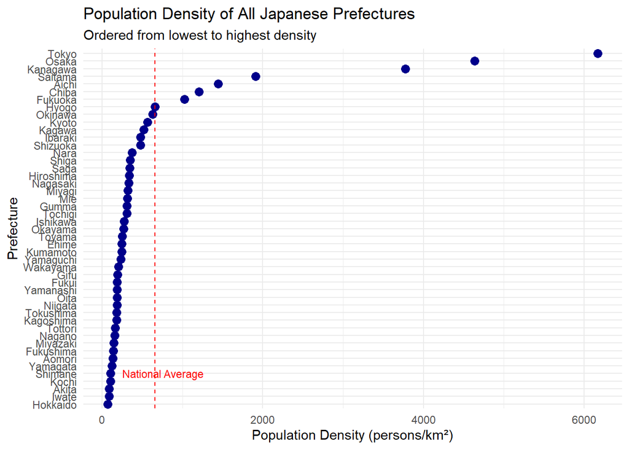

```r
# Dot plot of all prefectures
ggplot(population_long, aes(x = reorder(city_name, population_density), y = population_density)) +
  geom_point(size = 3, color = "darkblue") +
  coord_flip() +
  labs(title = "Population Density of All Japanese Prefectures",
       subtitle = "Ordered from lowest to highest density",
       x = "Prefecture",
       y = "Population Density (persons/km²)") +
  theme_minimal() +
  geom_hline(yintercept = mean(population_long$population_density),
             linetype = "dashed", color = "red", size = 0.5) +
  annotate("text", x = 5, y = mean(population_long$population_density) + 100,
           label = "National Average", color = "red", size = 3)
```

## **Dataset 3:** takeout spending habit by generation.

The original takeout spending dataset contained 12 rows and 7 columns, with 5 generations: Gen Z, Millennials, Gen X, Baby Boomers, Silent Gen. and their monthly spending columns from January to June. After transformation, the dataset was reshaped into long format with 30 rows and 3 columns: generation, month and spending. This transformed datasets is in tidy structure are are ready for data analysis and visualization.

```r
# Read the takeout spending CSV file
takeout_data <- read.csv("https://raw.githubusercontent.com/xiaofeimei1/sale-trend-analysis/refs/heads/main/takeoutspending.csv",
                         stringsAsFactors = FALSE,
                         check.names = FALSE)

# Print original columns
print(names(takeout_data))
```

```
[1] "generation" "Jan"        "Feb"        "Mar"        "Apr"
[6] "May"        "Jun"
```

```r
# Show structure of original data
str(takeout_data)
```

```
'data.frame':   12 obs. of  7 variables:
 $ generation: chr  "Gen Z" "Millenials" "Gen X" "Baby Boomers" ...
 $ Jan       : int  185 240 195 120 75 NA NA NA NA NA ...
 $ Feb       : int  172 228 188 115 70 NA NA NA NA NA ...
 $ Mar       : int  198 255 205 130 82 NA NA NA NA NA ...
 $ Apr       : int  210 270 215 140 88 NA NA NA NA NA ...
 $ May       : int  205 265 210 135 85 NA NA NA NA NA ...
 $ Jun       : int  225 285 220 145 90 NA NA NA NA NA ...
```

```r
# Show first few rows of original data
print("First few rows of original takeout data:")
```

```
[1] "First few rows of original takeout data:"
```

```r
print(head(takeout_data))
```

```
    generation Jan Feb Mar Apr May Jun
1        Gen Z 185 172 198 210 205 225
2   Millenials 240 228 255 270 265 285
3        Gen X 195 188 205 215 210 220
4 Baby Boomers 120 115 130 140 135 145
5   Silent Gen  75  70  82  88  85  90
6               NA  NA  NA  NA  NA  NA
```

```r
# Clean the data first - remove empty rows
takeout_data_clean <- takeout_data |>
  filter(!is.na(generation) & generation != "") |>  # Remove rows with empty generation
  select(1:7)

# Transform from wide to long
takeout_long <- takeout_data_clean |>
  pivot_longer(
    cols = -generation,  # All month columns except generation
    names_to = "month",
    values_to = "spending"
  ) |>
  mutate(
    month = as.character(month),  #  month in character
    spending = as.numeric(spending),  #  spending is numericr
    month = factor(month, levels = c("Jan", "Feb", "Mar", "Apr", "May", "Jun"), ordered = TRUE)
  ) |>
  arrange(generation, month)
# Show transformed dataset results
print(names(takeout_long))
```

```
[1] "generation" "month"      "spending"
```

```r
print("Structure of transformed data:")
```

```
[1] "Structure of transformed data:"
```

```r
str(takeout_long)
```

```
tibble [30 × 3] (S3: tbl_df/tbl/data.frame)
 $ generation: chr [1:30] "Baby Boomers" "Baby Boomers" "Baby Boomers" "Baby Boomers" ...
 $ month     : Ord.factor w/ 6 levels "Jan"<"Feb"<"Mar"<..: 1 2 3 4 5 6 1 2 3 4 ...
 $ spending  : num [1:30] 120 115 130 140 135 145 195 188 205 215 ...
```

```r
print("All rows of transformed dataset:")
```

```
[1] "All rows of transformed dataset:"
```

```r
print(takeout_long)
```

```
# A tibble: 30 × 3
   generation   month spending
   <chr>        <ord>    <dbl>
 1 Baby Boomers Jan        120
 2 Baby Boomers Feb        115
 3 Baby Boomers Mar        130
 4 Baby Boomers Apr        140
 5 Baby Boomers May        135
 6 Baby Boomers Jun        145
 7 Gen X        Jan        195
 8 Gen X        Feb        188
 9 Gen X        Mar        205
10 Gen X        Apr        215
# ℹ 20 more rows
```

```r
print(paste("Total rows:", nrow(takeout_long)))
```

```
[1] "Total rows: 30"
```

```r
print(paste("Number of generations:", length(unique(takeout_long$generation))))
```

```
[1] "Number of generations: 5"
```

```r
print(paste("Months covered:", paste(levels(takeout_long$month), collapse = ", ")))
```

```
[1] "Months covered: Jan, Feb, Mar, Apr, May, Jun"
```

```r
# average spending by generation
print("Average spending by generation:")
```

```
[1] "Average spending by generation:"
```

```r
takeout_long |>
  group_by(generation) |>
  summarise(avg_spending = mean(spending, na.rm = TRUE)) %>%
  arrange(desc(avg_spending))
```

```
# A tibble: 5 × 2
  generation   avg_spending
  <chr>               <dbl>
1 Millenials          257.
2 Gen X               206.
3 Gen Z               199.
4 Baby Boomers        131.
5 Silent Gen           81.7
```

```r
# average spending by month
print("Average spending by month:")
```

```
[1] "Average spending by month:"
```

```r
takeout_long |>
  group_by(month) |>
  summarise(avg_spending = mean(spending, na.rm = TRUE))
```

```
# A tibble: 6 × 2
  month avg_spending
  <ord>        <dbl>
1 Jan           163
2 Feb           155.
3 Mar           174
4 Apr           185.
5 May           180
6 Jun           193
```

Data analysis and visualization to identify which generation spends the most on takeout per month and to find out monthly spending trends across different generational groups.

Regarding monthly trends, the analysis shows a upward pattern from January to June across all generations, indicating that takeout spending generally increases as the year progresses from winter to summer months. This seasonal trend, combined with generational differences, could be valuable infomation to study consumer behavior and for company to potential targeting specific generation to promote their food products.

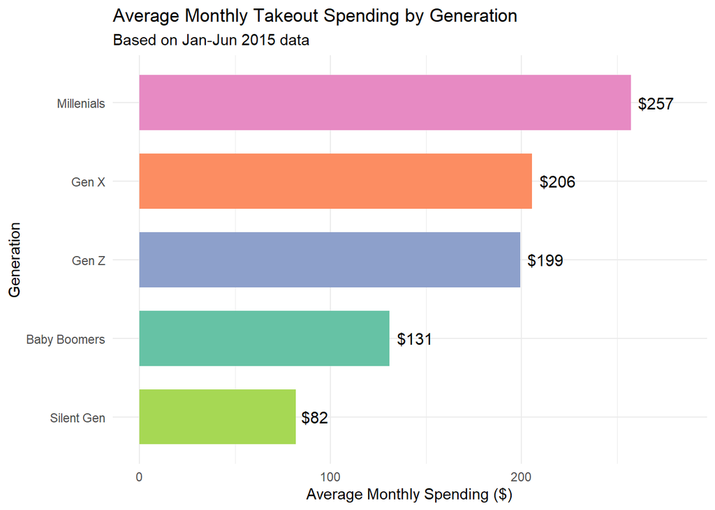

```r
generation_summary <- takeout_long |>
  group_by(generation) |>
  summarise(
    Avg_Monthly = mean(spending, na.rm = TRUE),
    .groups = 'drop'
  ) |>
  arrange(desc(Avg_Monthly))

# Bar chart - Average monthly spending by generation
ggplot(generation_summary, aes(x = reorder(generation, Avg_Monthly), y = Avg_Monthly, fill = generation)) +
  geom_bar(stat = "identity", width = 0.7) +
  coord_flip() +
  labs(title = "Average Monthly Takeout Spending by Generation",
       subtitle = "Based on Jan-Jun 2015 data",
       x = "Generation",
       y = "Average Monthly Spending ($)") +
  theme_minimal() +
  theme(legend.position = "none") +
  geom_text(aes(label = paste0("$", round(Avg_Monthly, 0))), hjust = -0.2, size = 4) +
  scale_fill_brewer(palette = "Set2") +
  ylim(0, max(generation_summary$Avg_Monthly) * 1.1)
```

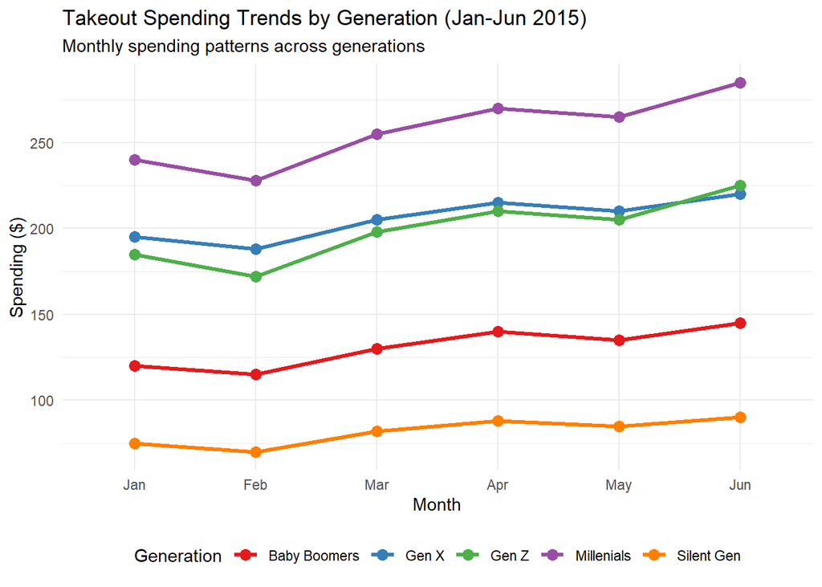

```r
# Line chart - Spending trends over months by generation
ggplot(takeout_long, aes(x = month, y = spending, group = generation, color = generation)) +
  geom_line(size = 1.2) +
  geom_point(size = 3) +
  labs(title = "Takeout Spending Trends by Generation (Jan-Jun 2015)",
       subtitle = "Monthly spending patterns across generations",
       x = "Month",
       y = "Spending ($)",
       color = "Generation") +
  theme_minimal() +
  theme(legend.position = "bottom") +
  scale_color_brewer(palette = "Set1")
```

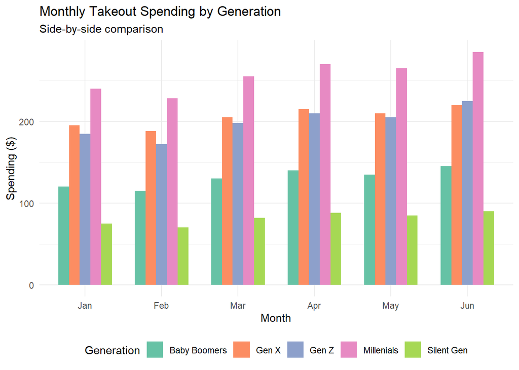

```r
#Comparison across months
ggplot(takeout_long, aes(x = month, y = spending, fill = generation)) +
  geom_bar(stat = "identity", position = "dodge", width = 0.7) +
  labs(title = "Monthly Takeout Spending by Generation",
       subtitle = "Side-by-side comparison",
       x = "Month",
       y = "Spending ($)",
       fill = "Generation") +
  theme_minimal() +
  theme(legend.position = "bottom") +
  scale_fill_brewer(palette = "Set2")
```

## **Summary**

This data analysis project focused on transforming three distinct datasets (global GDP, Japanese prefecture population density, and generational takeout spending) from wide format to long format to enable more effective analysis and visualization. Wide format has data of same category across multiple columns, making comparative analysis more difficult. The transformed data made filtering easier, enhanced grouping and aggregation when doing analysis. This data transformation to get tidy data is essential part for complex data analysis.